# 04_is_curve_a_function

## 04_is_curve_a_function

#### Question

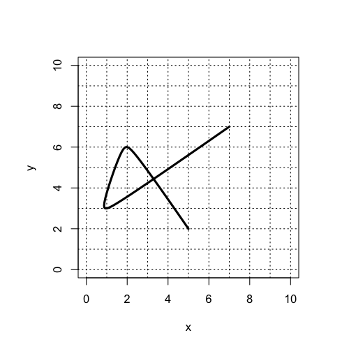

1. Is this curve consistent with $y$ being a function of $x$?

   Is this curve consistent with $x$ being a function of $y$?

   Is this curve consistent with a one-to-one function?

#### Question

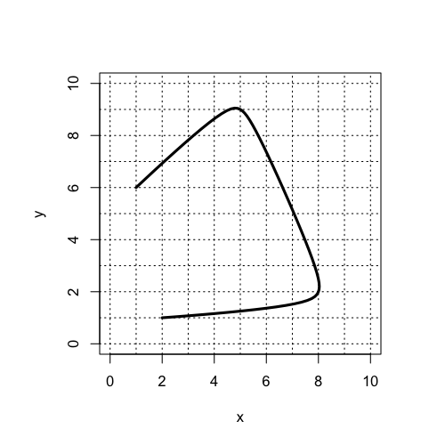

2. Is this curve consistent with $y$ being a function of $x$?

   Is this curve consistent with $x$ being a function of $y$?

   Is this curve consistent with a one-to-one function?

#### Question

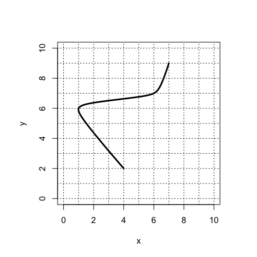

3. Is this curve consistent with $y$ being a function of $x$?

   Is this curve consistent with $x$ being a function of $y$?

   Is this curve consistent with a one-to-one function?

#### Question

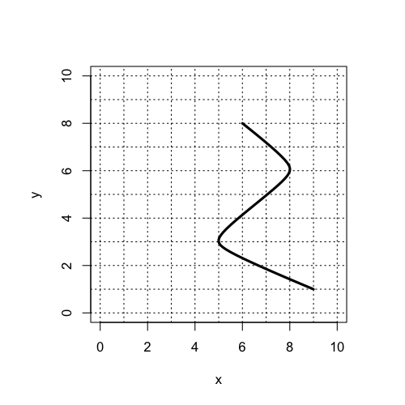

4. Is this curve consistent with $y$ being a function of $x$?

   Is this curve consistent with $x$ being a function of $y$?

   Is this curve consistent with a one-to-one function?

#### Question

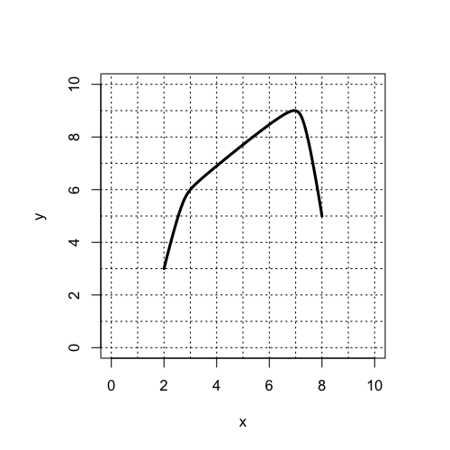

5. Is this curve consistent with $y$ being a function of $x$?

   Is this curve consistent with $x$ being a function of $y$?

   Is this curve consistent with a one-to-one function?

#### Question

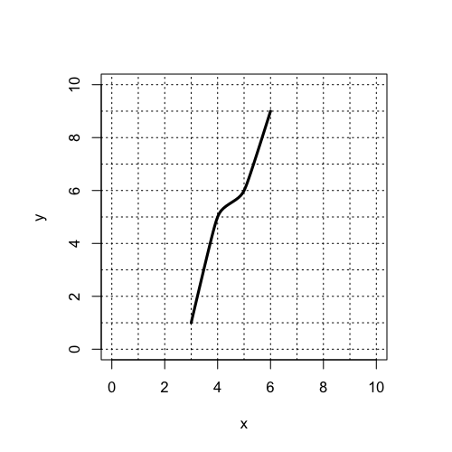

6. Is this curve consistent with $y$ being a function of $x$?

   Is this curve consistent with $x$ being a function of $y$?

   Is this curve consistent with a one-to-one function?

#### Question

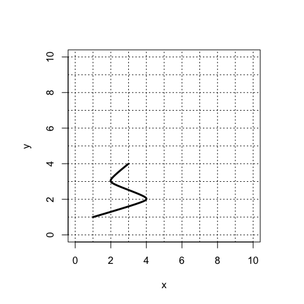

7. Is this curve consistent with $y$ being a function of $x$?

   Is this curve consistent with $x$ being a function of $y$?

   Is this curve consistent with a one-to-one function?

#### Question

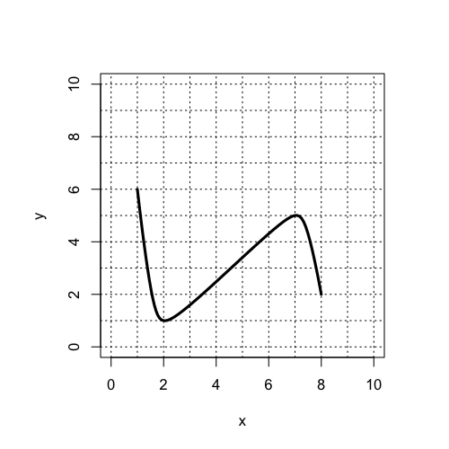

8. Is this curve consistent with $y$ being a function of $x$?

   Is this curve consistent with $x$ being a function of $y$?

   Is this curve consistent with a one-to-one function?